# A Time Series Analysis Of Household Energy Usage

Jack Keaveny

2025-03-17

# Introduction

A Time-Series Analysis of Household Energy Usage

Name: Jack Keaveny

Email: jkeaveny@ucsb.edu

For this project, I chose to work with a data set off of [Kaggle](https://www.kaggle.com/datasets/jaganadhg/house-hold-energy-data?resource=download) containing information on household energy usage across an apartment complex. I really wanted to use this data because I am very interested in rising energy costs and what they could possibly mean for our future. It’s very important to be aware of energy usage trends and price changes, especially with patterns of global warming and worldwide population growth.

Some individuals online have performed their own analysis on this data set, but I’m going to be doing a complete ARIMA and Spectral Analysis on this data, give my own 12-month forecast, and hope to come to some sort of conclusion as to whether some sort of pattern can be found. # Data

This data set contains 70.4k observations, each taking place 15 minutes apart starting at 10/26/2016 and ending at 10/23/2018. There are 8 columns. ‘TYPE’ determines type of energy usage, ‘DATE’ is the date, ‘START.TIME’ is the start time of the measurement, ‘END.TIME’ is the end time of the measurement, ‘USAGE’ measures energy usage in kWh, ‘UNITS’ only contains the value kWh, and ‘COST’ contains the cost of electricity in dollar amount. The data was collected by the author’s energy company in their apartment building over the span of two years.

Let’s take a quick look at the distributions of usage, our target variable.

```
##    Min. 1st Qu.  Median    Mean 3rd Qu.    Max.
##  0.0000  0.0300  0.0500  0.1219  0.1200  2.3600
```

Nothing seems off here and looking through the rest of the data, it appears cleaned and ready to be modeled.

# Methodology

Here’s a quick look at the time series visual, along with the ACF and PACF. We also want to perform an augmented Dickey-Fuller test to see if any differencing is necessary.

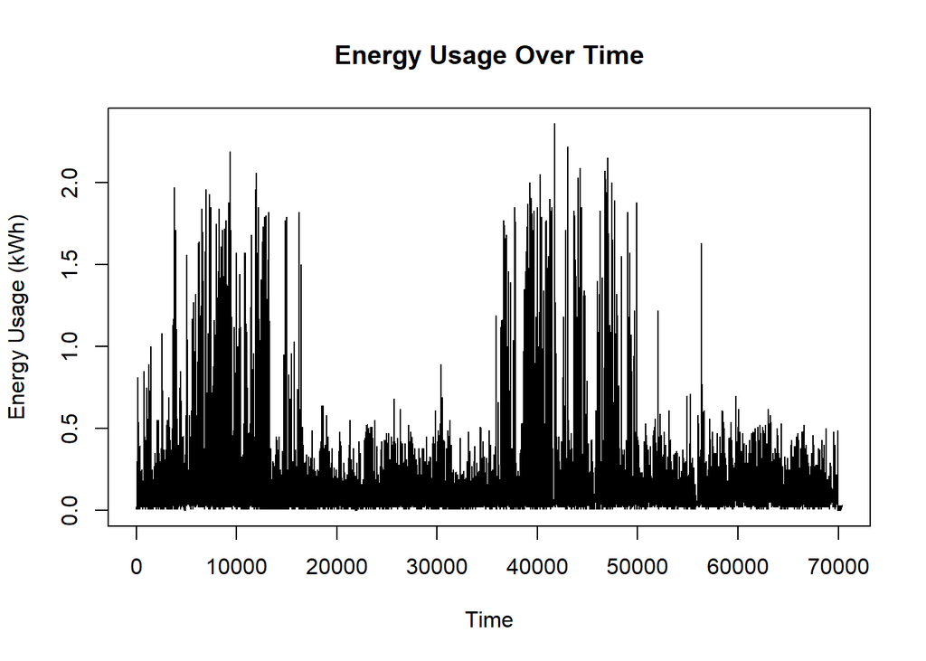

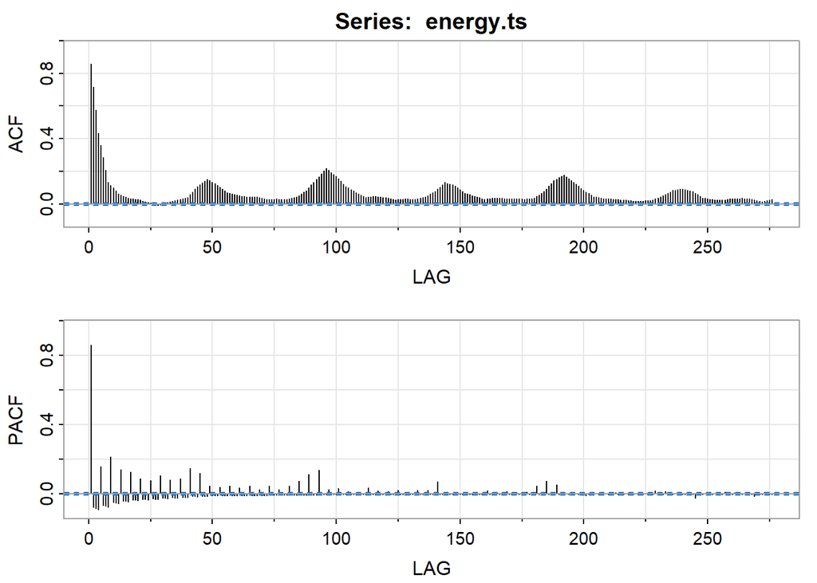

```
## [1] 0.01
```

Our data is stationary according to our low p-value and no differencing is needed. For our ACF, we see mounds of spikes every 45 or so lags, clearly indicating some sort of pattern in the data. The PACF is a little harder to interpret with lots of spikes within the first 50 or so lags and then very few past that. We can also observe in our simple time series plot that some sort of recurring pattern may be occurring, but more evidence is needed of course.

# Modeling and Results

## ARIMA

Now, we are ready to create our ARIMA model.

```
## Series: energy.ts
## ARIMA(0,1,0)
##
## sigma^2 = 0.01253:  log likelihood = 54252.55
## AIC=-108503.1   AICc=-108503.1   BIC=-108493.9
```

The auto.arima function gave us essentially a random walk model, but I don’t think this is correct. Let’s use what we observed in the ACF and PACF visuals to help create a better model.

```
## Series: energy.ts
## ARIMA(2,0,2) with non-zero mean
##
## Coefficients:
##          ar1     ar2     ma1      ma2    mean
##       0.0111  0.7087  0.9937  -0.0051  0.1219
## s.e.  0.0040  0.0029  0.0048   0.0046  0.0028
##
## sigma^2 = 0.01072:  log likelihood = 59735.55
## AIC=-119459.1   AICc=-119459.1   BIC=-119404.1
##
## Training set error measures:
##                         ME      RMSE        MAE MPE MAPE     MASE          ACF1
## Training set -3.021441e-07 0.1035318 0.03301674 NaN  Inf 1.474206 -0.0007172168
```

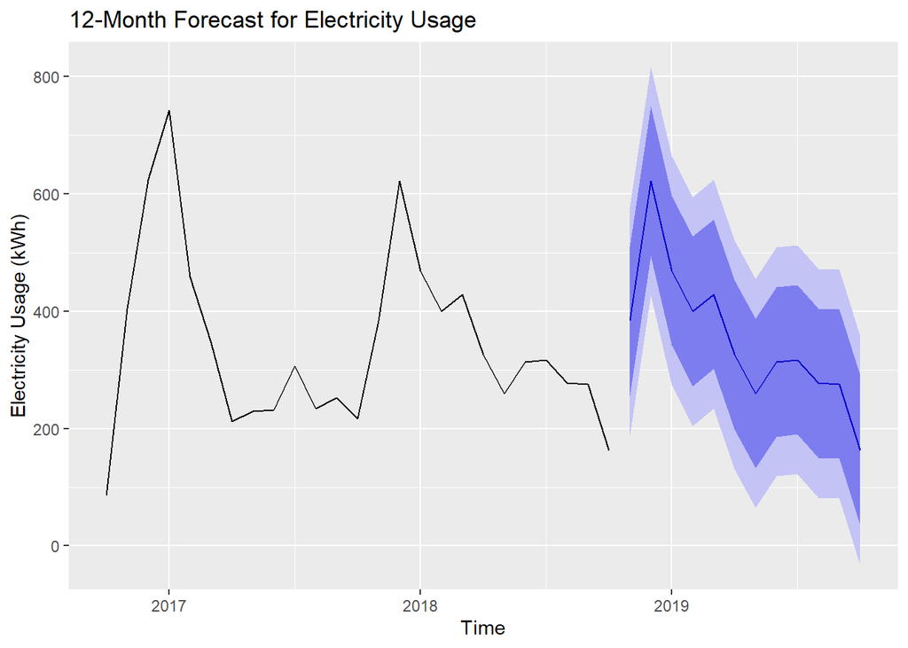

Our model’s 12-month prediction seems fairly accurate, based on the very apparent pattern in the data. I believe that this seasonality is likely due to the actual changing of seasons. In the winter, people are more likely to heat their homes which requires an immense amount of electricity. We see in this graph that the usage spikes are occurring towards the beginning of each year during winter.

## Spectral Analysis

Now, let’s commence our spectral analysis.

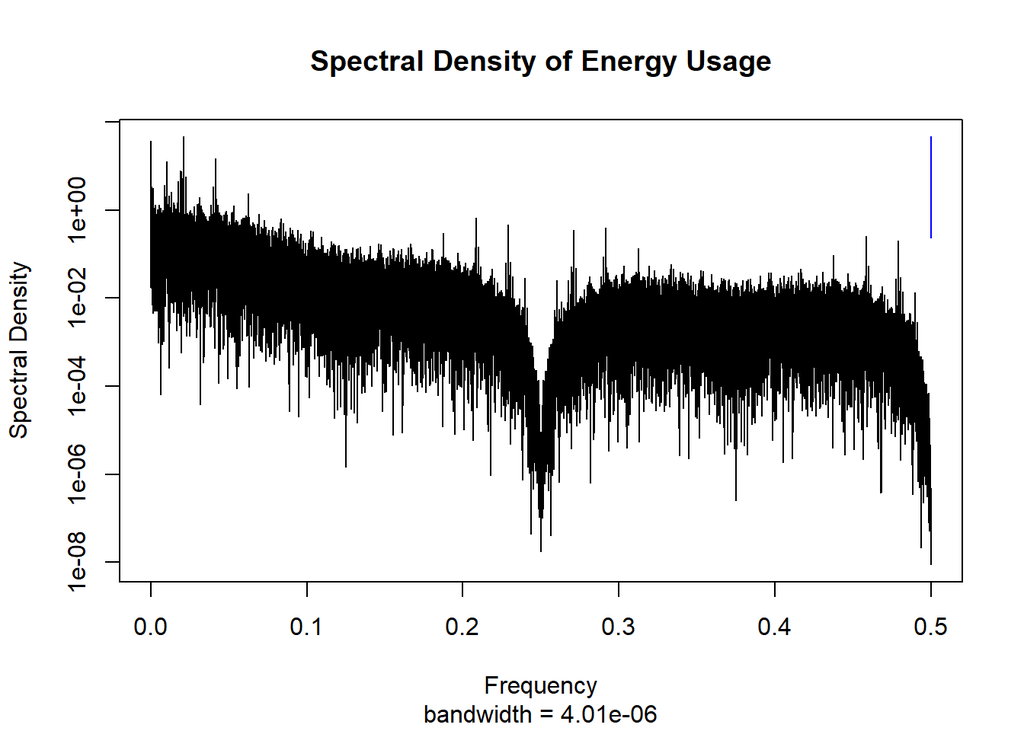

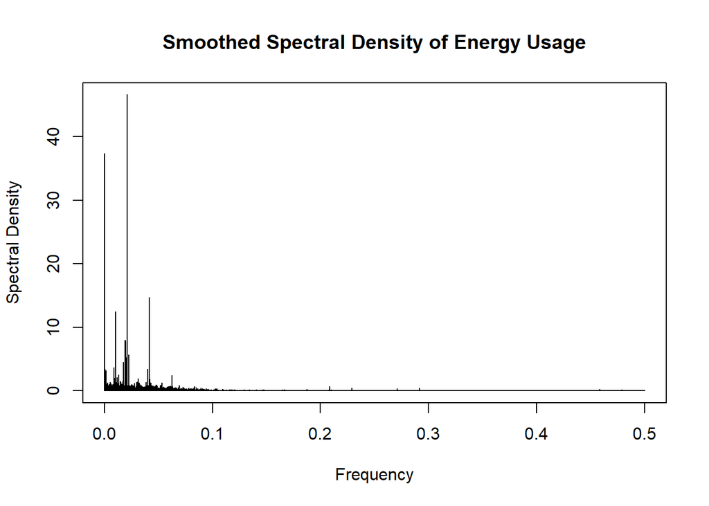

```
## Bandwidth: 0 | Degrees of Freedom: 11.1 | split taper: 10%
```

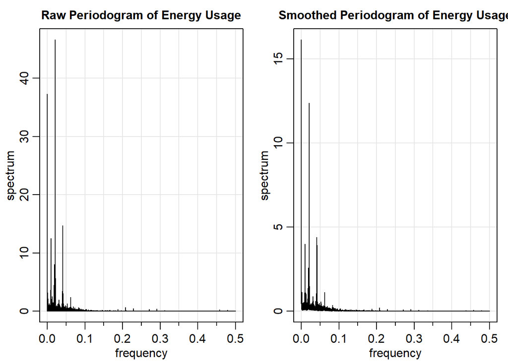

# Conclusion

Thanks for a great quarter!